# Overall Health - Statistical Modeling

Author

Courtney Green

```r
library(tidyverse)
library(readr)
df <- read_csv("../data/clean_data/merged_data.csv", show_col_types = FALSE)

# Filter out rows with missing values in critical columns
df <- df %>%
  filter(!is.na(overall_health_ranking) &
         !is.na(coverage_access_and_affordability) &
         !is.na(health_care_quality_and_prevention) &
         !is.na(health_outcomes) &
         !is.na(medicaid_expansion_status) &
         !is.na(state_requires_coverage_of_prescription_contraception))
#head(df)
```

## Overall Health

### Overall Health Ranking by Abortion Policy

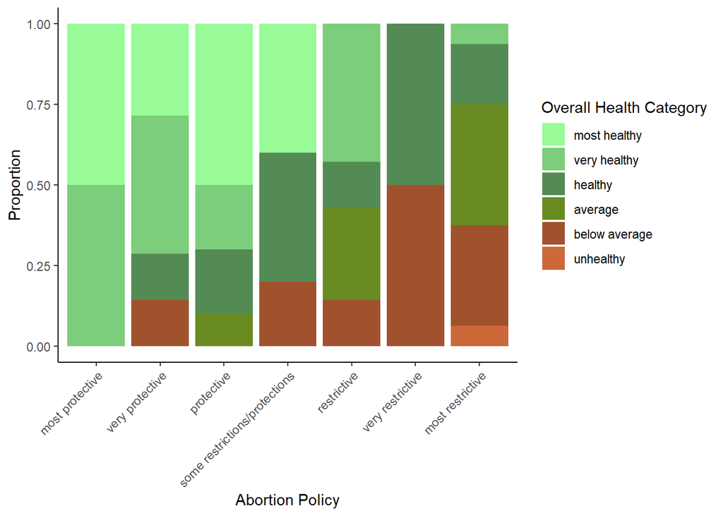

```r
# Reorder the levels of abortion policies
df$abortion_policies <- factor(df$abortion_policies,
                              levels = c("most protective", "very protective",
                                         "protective", "some restrictions/protections",
                                         "restrictive", "very restrictive", "most restrictive"))

# Bin overall_health_ranking into categories
df$overall_health_category <- cut(df$overall_health_ranking,
                                  breaks = c(-Inf, 10, 20, 30, 40, 50, Inf),
                                  labels = c("most healthy", "very healthy",
                                             "healthy", "average",
                                             "below average", "unhealthy"))

# Stacked bar plot by abortion policy
ggplot(df, aes(x = abortion_policies, fill = overall_health_category)) +
  geom_bar(position = "fill") +
  labs(x = "Abortion Policy",
       y = "Proportion",
       fill = "Overall Health Category") +
  scale_fill_manual(values = c("palegreen", "palegreen3", "palegreen4",
                                "olivedrab4", "sienna", "sienna3", "red")) +
  theme_classic() +
  theme(axis.text.x = element_text(angle = 45, hjust = 1))
```

This plot reveals that states with “most protective” abortion policies tend to have the highest proportions of “most healthy” and “very healthy” health outcomes. In contrast, as policies become more restrictive, there is an apparent increase in the proportion of states categorized as “unhealthy” or “below average.” **This suggests that states with restrictive abortion policies are not only limiting access to reproductive healthcare but may also be falling behind in fostering broader public health outcomes.** These restrictive states disproportionately represent environments where overall health conditions are poorer, potentially reflecting a lack of investment in comprehensive healthcare systems or preventative care infrastructure.

Alternatively, **states with protective abortion policies appear to align with stronger public health systems, where access to care and preventative measures may contribute to better overall health rankings.** This pattern underscores a broader connection between policy decisions prioritizing individual health rights and the overall well-being of a population.

```r
# Kruskal-Wallis Test: captures difference in overall_healths numeric rankings
kruskal_test <- kruskal.test(overall_health_ranking ~ abortion_policies, data = df)
print(kruskal_test)
```

```
    Kruskal-Wallis rank sum test

data:  overall_health_ranking by abortion_policies
Kruskal-Wallis chi-squared = 23.649, df = 6, p-value = 0.0006058
```

The **Kruskal-Wallis Test (χ² = 23.649, df = 6, p = 0.0006058)** reveals statistically significant differences in the numeric overall health rankings across the seven levels of abortion policy restrictiveness. This suggests that abortion policy restrictiveness correlates with variations in health outcomes. The low p-value (< 0.05) indicates that these differences are unlikely to have occurred by chance. This result supports the observation from the stacked bar plot: more restrictive abortion policies tend to align with poorer health outcomes, while more protective policies are associated with better health outcomes.

Now we will perform linear regression to investigate the direction of this relationship:

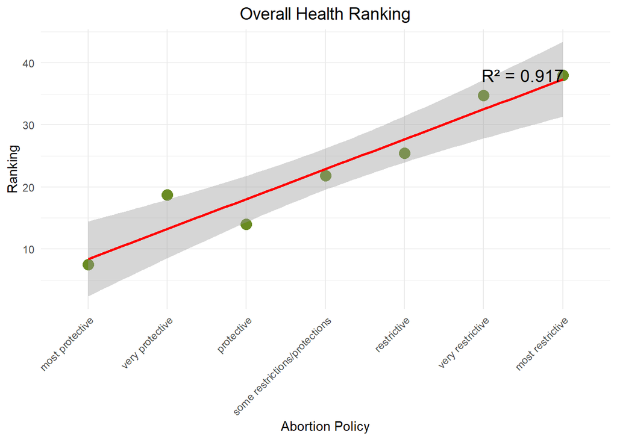

```r
# Linear Regression
processed_data <- df %>%
  group_by(abortion_policies) %>%
  summarise(avg_ranking = mean(overall_health_ranking, na.rm = TRUE))

# Fit linear model to calculate R-squared
lm_model <- lm(avg_ranking ~ as.numeric(abortion_policies), data = processed_data)
r_squared <- round(summary(lm_model)$r.squared, 3)

# Plot with R-squared annotation
ggplot(processed_data, aes(x = abortion_policies, y = avg_ranking)) +
  geom_point(size = 4, color = "olivedrab4") +
  geom_smooth(aes(group = 1), method = "lm", se = TRUE, color = "red") +
  labs(title = "Overall Health Ranking",
       x = "Abortion Policy",
       y = "Ranking") +
  annotate("text",
           x = length(levels(processed_data$abortion_policies)) - 0.5,
           y = max(processed_data$avg_ranking),
           label = paste0("R² = ", r_squared),
           size = 5,
           color = "black") +
  theme_minimal() +
  theme(axis.text.x = element_text(angle = 45, hjust = 1),
        plot.title = element_text(hjust = 0.5, size = 14))
```

### Medicaid Expansion Status by Abortion Policy

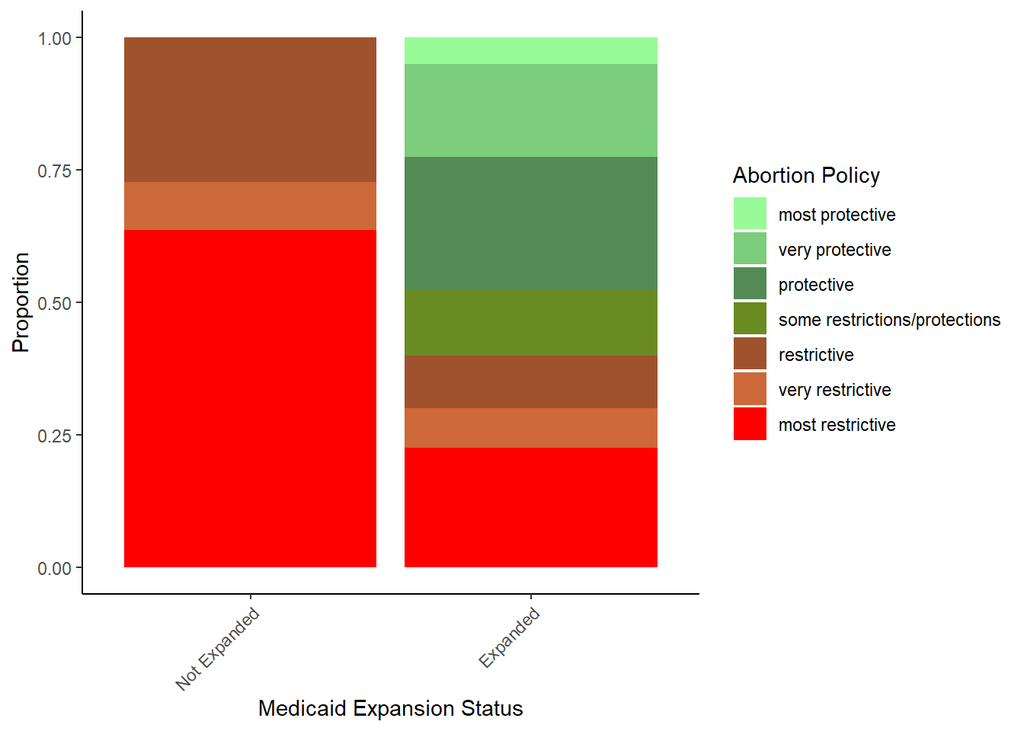

```r
df$medicaid_expansion <- factor(df$medicaid_expansion_status, levels = c("0", "1"))

# Stacked bar plot of Medicaid Expansion Status with Abortion Policies as Fill
ggplot(df, aes(x = medicaid_expansion, fill = abortion_policies)) +
  geom_bar(position = "fill") +
  labs(x = "Medicaid Expansion Status",
       y = "Proportion",
       fill = "Abortion Policy") +
  scale_x_discrete(labels = c("0" = "Not Expanded", "1" = "Expanded")) +
  scale_fill_manual(values = c("palegreen", "palegreen3", "palegreen4",
                                "olivedrab4", "sienna", "sienna3", "red")) +
  theme_classic() +
  theme(axis.text.x = element_text(angle = 45, hjust = 1)) # Rotate x-axis labels
```

This plot highlights how states that have not expanded Medicaid are disproportionately associated with more restrictive abortion policies. In contrast, states that have expanded Medicaid show a higher proportion of protective and less restrictive abortion policies. **This pattern suggests a potential relationship between policy choices around healthcare access (Medicaid expansion) and reproductive rights (abortion policies), where more progressive health policies align with broader healthcare access.**

```r
# Fisher's Exact Test
contingency_table <- table(df$medicaid_expansion_status, df$abortion_policies)

fisher_test_result <- fisher.test(contingency_table)
print(fisher_test_result)
```

```
    Fisher's Exact Test for Count Data

data:  contingency_table
p-value = 0.03091
alternative hypothesis: two.sided
```

The **Fisher’s Exact Test** yielded a p-value of **0.03091**, indicating a statistically significant association between Medicaid expansion status and abortion policies. This suggests that the distribution of Medicaid expansion (expanded vs. not expanded) varies significantly across different abortion policy categories. States’ decisions on Medicaid expansion may align with their stance on abortion policies.

Now we will perform logistic regression to investigate the direction of this relationship:

```r
# Check assumptions for logistic regression
table(df$medicaid_expansion_status, df$abortion_policies)
```

```
    most protective very protective protective some restrictions/protections
  0               0               0          0                             0
  1               2               7         10                             5

    restrictive very restrictive most restrictive
  0           3                1                7
  1           4                3                9
```

Sample sizes for logistic regression are too small, so we must use exact logistic regression to account for this size and separation:

```r
library(logistf)

# Fit the exact logistic regression model
fit <- logistf(medicaid_expansion_status ~ factor(abortion_policies), data = df)

# View the results
summary(fit)
```

```
logistf(formula = medicaid_expansion_status ~ factor(abortion_policies),
    data = df)

Model fitted by Penalized ML
Coefficients:
                                                             coef se(coef)
(Intercept)                                             1.6094379 1.549193
factor(abortion_policies)very protective                1.0986123 2.129163
factor(abortion_policies)protective                     1.4350845 2.120198
factor(abortion_policies)some restrictions/protections  0.7884574 2.140518
factor(abortion_policies)restrictive                   -1.3581235 1.705267
factor(abortion_policies)very restrictive              -0.7621401 1.830951
factor(abortion_policies)most restrictive              -1.3730491 1.624376
                                                       lower 0.95 upper 0.95
(Intercept)                                            -0.8993577   6.536132
factor(abortion_policies)very protective               -4.2449368   6.453876
factor(abortion_policies)protective                    -3.8986862   6.781282
factor(abortion_policies)some restrictions/protections -4.5677245   6.155104
factor(abortion_policies)restrictive                   -6.4096451   1.555766
factor(abortion_policies)very restrictive              -5.9125654   2.600042
factor(abortion_policies)most restrictive              -6.3586197   1.327338
                                                           Chisq         p
(Intercept)                                            1.4555158 0.2276449
factor(abortion_policies)very protective               0.2579603 0.6115249
factor(abortion_policies)protective                    0.4335919 0.5102317
factor(abortion_policies)some restrictions/protections 0.1335787 0.7147500
factor(abortion_policies)restrictive                   0.7522045 0.3857792
factor(abortion_policies)very restrictive              0.1853520 0.6668136
factor(abortion_policies)most restrictive              0.8859352 0.3465812
                                                       method
(Intercept)                                                 2
factor(abortion_policies)very protective                    2
factor(abortion_policies)protective                         2
factor(abortion_policies)some restrictions/protections      2
factor(abortion_policies)restrictive                        2
factor(abortion_policies)very restrictive                   2
factor(abortion_policies)most restrictive                   2

Method: 1-Wald, 2-Profile penalized log-likelihood, 3-None

Likelihood ratio test=10.87201 on 6 df, p=0.09241346, n=51
Wald test = 12.68851 on 6 df, p = 0.04825799
```

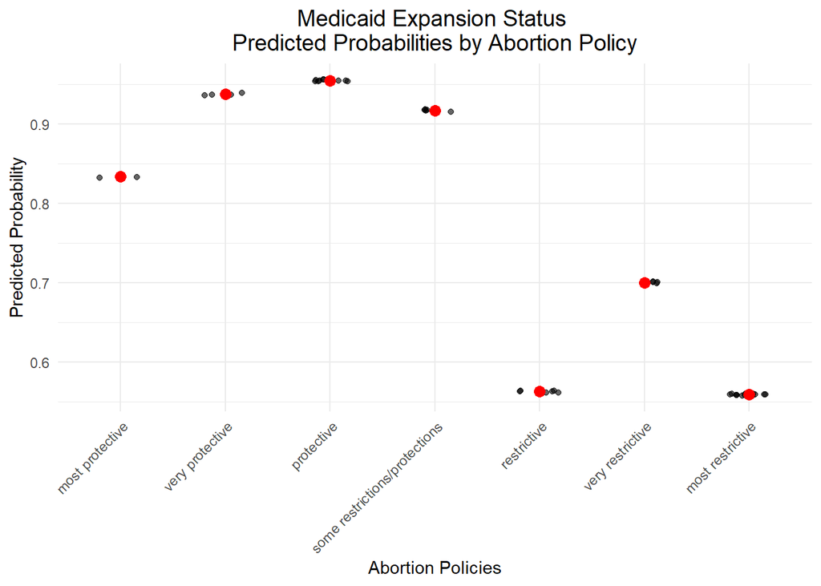

```r
# Generate predicted probabilities
df$predicted_prob <- predict(fit, type = "response")

# visualize
ggplot(df, aes(x = abortion_policies, y = predicted_prob)) +
  geom_point(position = position_jitter(width = 0.2), alpha = 0.6) +
  stat_summary(fun = mean, geom = "point", color = "red", size = 3) +
  labs(x = "Abortion Policies",
       y = "Predicted Probability",
       title = "Medicaid Expansion Status \nPredicted Probabilities by Abortion Policy") +
  theme_minimal() +
  theme(axis.text.x = element_text(angle = 45, hjust = 1),
        plot.title = element_text(hjust = 0.5, size = 14))
```

The **exact logistic regression model yields a p-value of 0.0483** from the Wald test, indicating that abortion policies are significantly associated with Medicaid expansion status. **The slope coefficients suggest that as abortion policies become more restrictive, the predicted probability of Medicaid expansion decreases.** The visualization reinforces this relationship, showing higher predicted probabilities of Medicaid expansion among states with protective abortion policies and sharply lower probabilities in states with restrictive abortion policies. **This pattern highlights a critical divide in policy decisions: states prioritizing broader reproductive rights are also more likely to expand healthcare access through Medicaid, whereas restrictive abortion policies align with reduced Medicaid expansion.** This underscores the broader policy implications of prioritizing access to healthcare and reproductive rights.

### Coverage, Access, and Affordability by Abortion Policy

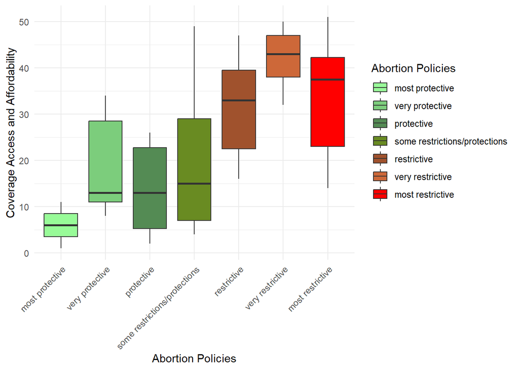

```r
# Boxplot for coverage and abortion policies
ggplot(df, aes(x = abortion_policies, y = coverage_access_and_affordability, fill = abortion_policies)) +
  geom_boxplot() +
  scale_fill_manual(values = c("palegreen", "palegreen3", "palegreen4",
                                "olivedrab4", "sienna", "sienna3", "red")) +
  labs(x = "Abortion Policies", y = "Coverage Access and Affordability", fill = "Abortion Policies") +
  theme_minimal() +
  theme(axis.text.x = element_text(angle = 45, hjust = 1))
```

States with “most protective” abortion policies tend to have better rankings (lower values), indicating higher coverage access and affordability. Conversely, states with more restrictive abortion policies exhibit worse rankings (higher values), suggesting reduced coverage access and affordability. This trend may reflect that states with protective abortion policies prioritize healthcare equity and access more effectively than those with restrictive policies.

This disparity also highlights inconsistencies in the priorities of restrictive states. States with protective abortion policies might integrate reproductive healthcare into broader healthcare initiatives, fostering better access and affordability. **In contrast, restrictive states, which often frame their policies as being “pro-life,” may focus on generalized or inconsistent healthcare frameworks, leading to poorer outcomes.** The lack of affordable and accessible healthcare in these states undermines their claims to protect life, as they fail to support the broader well-being of the populations they govern. These findings underscore both the interconnectedness between reproductive healthcare policy and overall healthcare accessibility and affordability, and the disconnect in restrictive states between policy rhetoric and actionable support for healthier communities.

```r
kruskal_test <- kruskal.test(coverage_access_and_affordability ~ abortion_policies, data = df)
print(kruskal_test)
```

```
    Kruskal-Wallis rank sum test

data:  coverage_access_and_affordability by abortion_policies
Kruskal-Wallis chi-squared = 22.583, df = 6, p-value = 0.0009489
```

The **Kruskal-Wallis test** yielded a **chi-squared value of 22.583 with 6 degrees of freedom and a p of 0.0009489.** This statistically significant result indicates that there are differences in coverage access and affordability rankings among the seven abortion policy levels. States with more restrictive abortion policies appear to have higher (worse) rankings for coverage access and affordability compared to states with more protective policies, reinforcing the association between policy restrictiveness and reduced access to affordable care.

```r
# Permutation Test Implementation for Coverage Access and Affordability
N <- 10000

# Observed ANOVA F-statistic
observed_anova <- aov(coverage_access_and_affordability ~ abortion_policies, data = df)
observed_F <- summary(observed_anova)[[1]][["F value"]][1]

# Permutation loop
set.seed(1234) # For reproducibility
perm_F <- numeric(N)

for (i in 1:N) {
  # Permute the response variable
  permuted_data <- df
  permuted_data$coverage_access_and_affordability <- sample(permuted_data$coverage_access_and_affordability)

  # Perform ANOVA on permuted data
  perm_anova <- aov(coverage_access_and_affordability ~ abortion_policies, data = permuted_data)
  perm_F[i] <- summary(perm_anova)[[1]][["F value"]][1]
}

# Calculate p-value
p_value <- mean(perm_F >= observed_F)

cat("Observed F-statistic:", observed_F, "\n")
```

```
Observed F-statistic: 6.089754
```

```r
cat("Permutation Test p-value:", p_value, "\n")
```

```
Permutation Test p-value: 1e-04
```

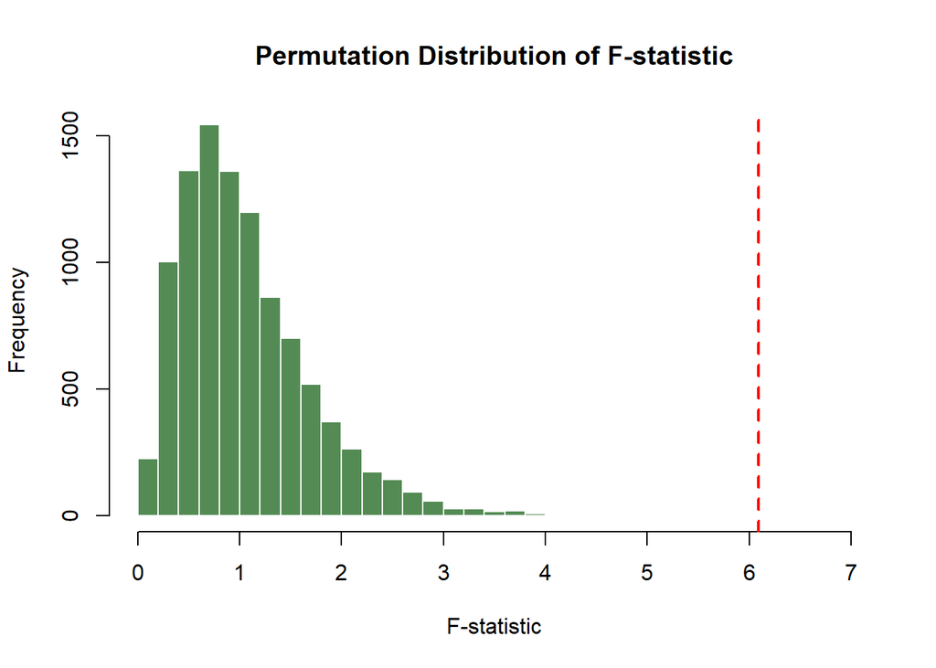

```r
# Plot the permutation F-statistics
hist(perm_F,
     breaks = 30,
     main = "Permutation Distribution of F-statistic",
     xlab = "F-statistic",
     col = "palegreen4",
     border = "white")

# F-statistic line
abline(v = observed_F,
       col = "red",
       lwd = 2,
       lty = 2)
```

**A permutation test** was performed on this data in addition to the Kruskal-Wallis test to ensure the robustness of the findings across different methods. The observed F-statistic of 6.089754 (indicated by the red dashed line) lies far to the right of the permutation distribution, representing F-statistics generated under the null hypothesis. The permutation test produced a statistically significant p-value of 1x10^-4, providing strong evidence that the observed differences in coverage access and affordability across abortion policy levels are unlikely to be due to random chance. This result supports the conclusion that coverage access and affordability rankings vary significantly by abortion policy level.

### Prescription Contraception Coverage Requirements by Abortion Policy

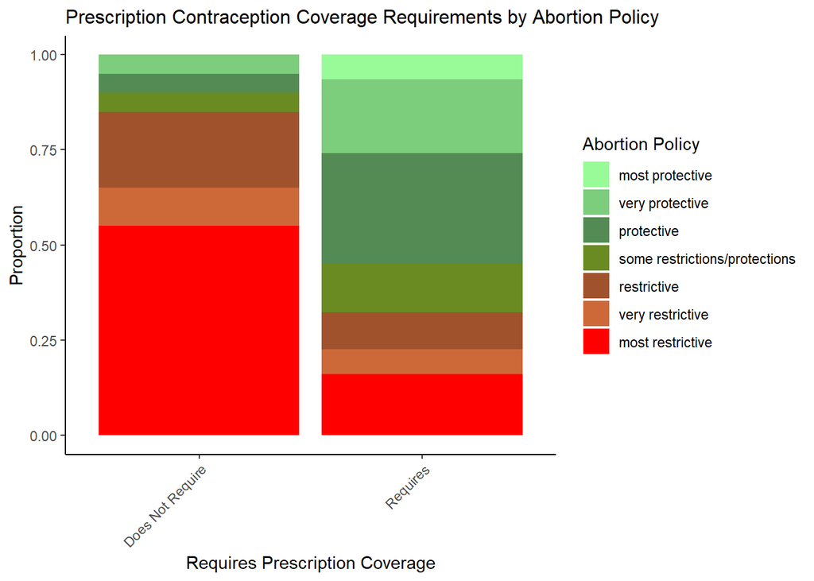

```r
df$requires_prescription <- factor(df$state_requires_coverage_of_prescription_contraception, levels = c("0", "1"))

# Stacked bar plot for Prescription Contraception Coverage Requirements
ggplot(df, aes(x = requires_prescription, fill = abortion_policies)) +
  geom_bar(position = "fill") +
  labs(x = "Requires Prescription Coverage",
       y = "Proportion",
       fill = "Abortion Policy",
       title = "Prescription Contraception Coverage Requirements by Abortion Policy") +
  scale_x_discrete(labels = c("0" = "Does Not Require", "1" = "Requires")) +
  scale_fill_manual(values = c("palegreen", "palegreen3", "palegreen4",
                                "olivedrab4", "sienna", "sienna3", "red")) +
  theme_classic() +
  theme(axis.text.x = element_text(angle = 45, hjust = 1),
        plot.title = element_text(hjust = 0, size = 12))
```

The stacked bar plot demonstrates that states that do not require prescription coverage are predominantly associated with more restrictive abortion policies, whereas states that require prescription coverage tend to align with more protective abortion policies.

This pattern reveals a significant gap in healthcare priorities among restrictive abortion policy states. **By failing to require prescription coverage, particularly for contraceptives, these states not only limit access to essential tools for preventing unintended pregnancies, effectively undermining efforts to reduce the need for abortions in the first place, but also neglect the broader healthcare needs of individuals.** Contraceptives are often prescribed to manage health conditions such as dysmenorrhea, endometriosis, or hormonal regulation, which can significantly impact quality of life. States with protective abortion policies, which typically require prescription coverage, demonstrate a more holistic approach to healthcare, supporting both reproductive autonomy and broader health outcomes.

```r
contingency_table <- table(df$state_requires_coverage_of_prescription_contraception, df$abortion_policies)
fisher_test_result <- fisher.test(contingency_table)
print(fisher_test_result)
```

```
    Fisher's Exact Test for Count Data

data:  contingency_table
p-value = 0.01764
alternative hypothesis: two.sided
```

The **Fisher’s Exact Test results yield a p-value of 0.01764**, indicating a statistically significant association between whether a state requires prescription coverage and its abortion policy. This suggests that the distribution of states requiring or not requiring prescription coverage is not independent of their abortion policy levels. The association highlights how policy decisions in these states may systematically limit or increase access to reproductive healthcare and broader health support systems, reinforcing disparities in healthcare infrastructure and prioritization.

Now, we will perform logistic regression to investigate the direction of this relationship:

```r
# Check assumptions for logistic regression
table(df$state_requires_coverage_of_prescription_contraception, df$abortion_policies)
```

```
    most protective very protective protective some restrictions/protections
  0               0               1          1                             1
  1               2               6          9                             4

    restrictive very restrictive most restrictive
  0           4                2               11
  1           3                2                5
```

Sample sizes for logistic regression are too small, so we must use exact logistic regression to account for this size and separation…

```r
# Logistic Regression
library(logistf)

# Fit logistic regression model
fit <- logistf(state_requires_coverage_of_prescription_contraception ~ factor(abortion_policies), data = df)

# View results
summary(fit)
```

```
logistf(formula = state_requires_coverage_of_prescription_contraception ~
    factor(abortion_policies), data = df)

Model fitted by Penalized ML
Coefficients:
                                                             coef se(coef)
(Intercept)                                             1.6094379 1.549193
factor(abortion_policies)very protective               -0.1431008 1.794579
factor(abortion_policies)protective                     0.2363888 1.780990
factor(abortion_policies)some restrictions/protections -0.5108256 1.813529
factor(abortion_policies)restrictive                   -1.8607523 1.705267
factor(abortion_policies)very restrictive              -1.6094379 1.788854
factor(abortion_policies)most restrictive              -2.3470369 1.633638
                                                       lower 0.95 upper 0.95
(Intercept)                                            -0.8993577  6.5361319
factor(abortion_policies)very protective               -5.2583237  3.1558062
factor(abortion_policies)protective                    -4.8662731  3.5104202
factor(abortion_policies)some restrictions/protections -5.6440931  2.8216151
factor(abortion_policies)restrictive                   -6.9149344  1.0302498
factor(abortion_policies)very restrictive              -6.7355228  1.5101927
factor(abortion_policies)most restrictive              -7.3414344  0.3645081
                                                             Chisq          p
(Intercept)                                            1.455515830 0.22764495
factor(abortion_policies)very protective               0.006456591 0.93595657
factor(abortion_policies)protective                    0.017133155 0.89585942
factor(abortion_policies)some restrictions/protections 0.083322594 0.77284423
factor(abortion_policies)restrictive                   1.489808677 0.22224615
factor(abortion_policies)very restrictive              0.950172752 0.32967533
factor(abortion_policies)most restrictive              2.814056557 0.09344182
                                                       method
(Intercept)                                                 2
factor(abortion_policies)very protective                    2
factor(abortion_policies)protective                         2
factor(abortion_policies)some restrictions/protections      2
factor(abortion_policies)restrictive                        2
factor(abortion_policies)very restrictive                   2
factor(abortion_policies)most restrictive                   2

Method: 1-Wald, 2-Profile penalized log-likelihood, 3-None

Likelihood ratio test=13.07125 on 6 df, p=0.04191838, n=51
Wald test = 11.61987 on 6 df, p = 0.07100654
```

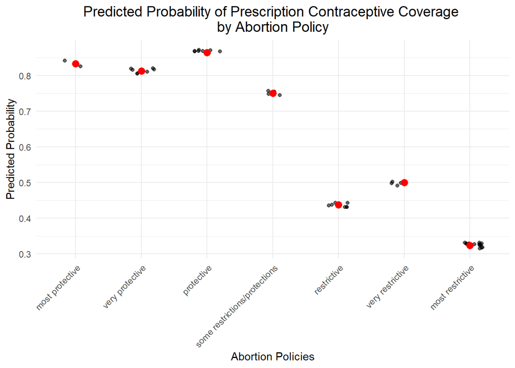

```r
# Generate predicted probabilities
df$predicted_prob <- predict(fit, type = "response")

# Visualize predicted probabilities
ggplot(df, aes(x = abortion_policies, y = predicted_prob)) +
  geom_point(position = position_jitter(width = 0.2), alpha = 0.6) +
  stat_summary(fun = mean, geom = "point", color = "red", size = 3) +
  labs(x = "Abortion Policies",
       y = "Predicted Probability",
       title = "Predicted Probability of Prescription Contraceptive Coverage \nby Abortion Policy") +
  theme_minimal() +
  theme(axis.text.x = element_text(angle = 45, hjust = 1),
        plot.title = element_text(hjust = 0.5, size = 14))
```

The **exact logistic regression analysis** provides evidence of a significant relationship between abortion policy restrictiveness and the likelihood of requiring prescription contraceptive coverage, as shown by the likelihood ratio test (p=0.0419). **The predicted probabilities visualized here demonstrate a clear gradient: states with more restrictive abortion policies consistently exhibit lower probabilities of requiring prescription contraceptive coverage compared to those with more protective policies.**

This trend highlights a potential disconnect in restrictive states, which often emphasize policies purportedly in favor of life but fail to mandate coverage for contraceptives that could prevent unintended pregnancies or support broader healthcare needs. On the other hand, states with protective abortion policies are more likely to require coverage, aligning with healthcare frameworks that prioritize both reproductive autonomy and overall well-being. These findings underscore how policy decisions around abortion can reflect broader approaches—or lack thereof—toward supporting individuals’ health and autonomy.

### Healthcare Quality and Prevention by Abortion Policy

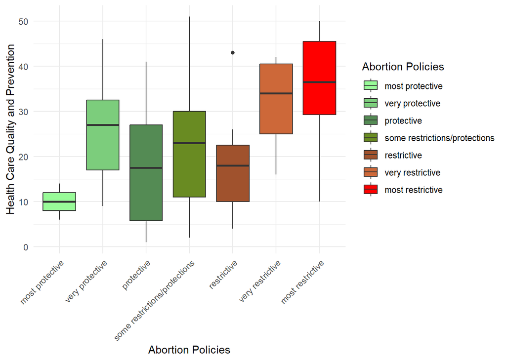

```r
# Boxplot for health care quality and prevention by abortion policies
ggplot(df, aes(x = abortion_policies, y = health_care_quality_and_prevention, fill = abortion_policies)) +
  geom_boxplot() +
  scale_fill_manual(values = c("palegreen", "palegreen3", "palegreen4",
                                "olivedrab4", "sienna", "sienna3", "red")) +
  labs(
    x = "Abortion Policies",
    y = "Health Care Quality and Prevention",
    fill = "Abortion Policies"
  ) +
  theme_minimal() +
  theme(
    axis.text.x = element_text(angle = 45, hjust = 1),
    legend.position = "right"
  )
```

```r
kruskal_test <- kruskal.test(health_care_quality_and_prevention ~ abortion_policies, data = df)
print(kruskal_test)
```

```
    Kruskal-Wallis rank sum test

data:  health_care_quality_and_prevention by abortion_policies
Kruskal-Wallis chi-squared = 14.09, df = 6, p-value = 0.02865
```

```r
# Permutation Test Implementation for Health Care Quality and Prevention
N <- 10000

# Observed ANOVA F-statistic
observed_anova <- aov(health_care_quality_and_prevention ~ abortion_policies, data = df)
observed_F <- summary(observed_anova)[[1]][["F value"]][1]

# Permutation loop
set.seed(1234) # For reproducibility
perm_F <- numeric(N)

for (i in 1:N) {
  # Permute the response variable
  permuted_data <- df
  permuted_data$health_care_quality_and_prevention <- sample(permuted_data$health_care_quality_and_prevention)

  # Perform ANOVA on permuted data
  perm_anova <- aov(health_care_quality_and_prevention ~ abortion_policies, data = permuted_data)
  perm_F[i] <- summary(perm_anova)[[1]][["F value"]][1]
}

# Calculate p-value
p_value <- mean(perm_F >= observed_F)

cat("Observed F-statistic:", observed_F, "\n")
```

```
Observed F-statistic: 2.812286
```

```r
cat("Permutation Test p-value:", p_value, "\n")
```

```
Permutation Test p-value: 0.0186
```

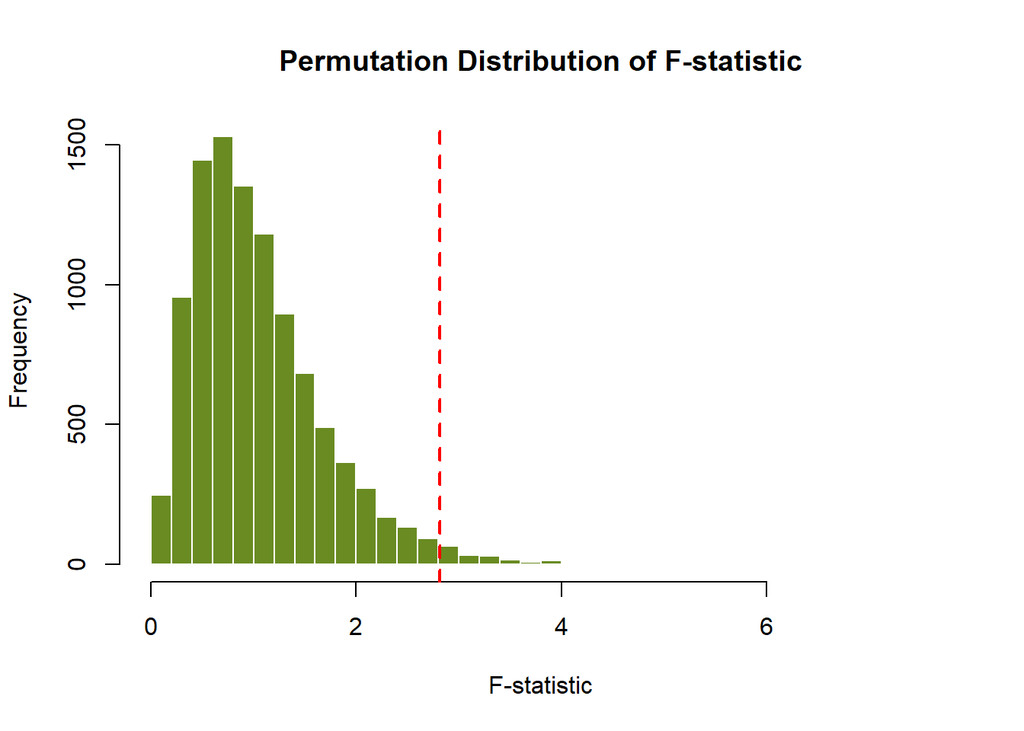

```r
# Plot the permutation F-statistics
hist(perm_F,
     breaks = 30,
     main = "Permutation Distribution of F-statistic",
     xlab = "F-statistic",
     col = "olivedrab4",
     border = "white")

# F-statistic line
abline(v = observed_F,
       col = "red",
       lwd = 2,
       lty = 2)
```

A **permutation test** was performed on the healthcare quality and prevention data in addition to the Kruskal-Wallis test to ensure the robustness of the findings across different statistical methods. The permutation test yielded a statistically significant p-value of 0.0186, confirming evidence that healthcare quality and prevention rankings differ among at least one of the abortion policy levels. This reinforces the conclusion that abortion policy restrictiveness is associated with variations in healthcare quality and prevention outcomes across states.

### Health Outcomes by Abortion Policy

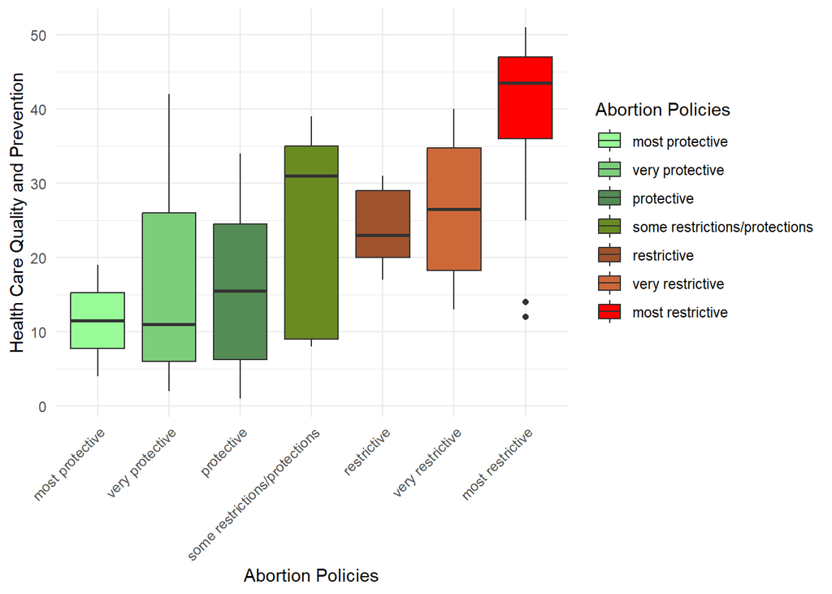

```r
# Boxplot for health outcomes by abortion policies
ggplot(df, aes(x = abortion_policies, y = health_outcomes, fill = abortion_policies)) +
  geom_boxplot() +
  scale_fill_manual(values = c("palegreen", "palegreen3", "palegreen4",
                                "olivedrab4", "sienna", "sienna3", "red")) +
  labs(
    x = "Abortion Policies",
    y = "Health Care Quality and Prevention",
    fill = "Abortion Policies"
  ) +
  theme_minimal() +
  theme(
    axis.text.x = element_text(angle = 45, hjust = 1),
    legend.position = "right"
  )
```

These **trends suggest that states with more restrictive abortion policies may lack broader investments in public health infrastructure and services, contributing to poorer overall health outcomes.** In contrast, states with protective abortion policies might prioritize comprehensive healthcare systems that address a wider array of health determinants. This disparity underscores the broader implications of policy decisions on public health and well-being, highlighting potential inequities in access to essential healthcare resources.

```r
kruskal_test <- kruskal.test(health_outcomes ~ abortion_policies, data = df)
print(kruskal_test)
```

```
    Kruskal-Wallis rank sum test

data:  health_outcomes by abortion_policies
Kruskal-Wallis chi-squared = 21.669, df = 6, p-value = 0.00139
```

The **Kruskal-Wallis** test for health outcomes across abortion policy levels reveals a chi-squared value of **21.669** with **6 degrees of freedom** and a **p-value of 0.00139**. This statistically significant result indicates that health outcomes vary meaningfully across at least one level of abortion policy. This reinforces the trends observed in the boxplot: states with “most protective” abortion policies tend to achieve better health outcomes, while those with “most restrictive” policies are associated with worse rankings.

```r
# Permutation Test Implementation for Health Outcomes by Abortion Policy
N <- 10000

# Observed ANOVA F-statistic
observed_anova <- aov(health_outcomes ~ abortion_policies, data = df)
observed_F <- summary(observed_anova)[[1]][["F value"]][1]

# Permutation loop
set.seed(1234) # For reproducibility
perm_F <- numeric(N)

for (i in 1:N) {
  # Permute the response variable
  permuted_data <- df
  permuted_data$health_outcomes <- sample(permuted_data$health_outcomes)

  # Perform ANOVA on permuted data
  perm_anova <- aov(health_outcomes ~ abortion_policies, data = permuted_data)
  perm_F[i] <- summary(perm_anova)[[1]][["F value"]][1]
}

# Calculate p-value
p_value <- mean(perm_F >= observed_F)

cat("Observed F-statistic:", observed_F, "\n")
```

```
Observed F-statistic: 5.608316
```

```r
cat("Permutation Test p-value:", p_value, "\n")
```

```
Permutation Test p-value: 2e-04
```

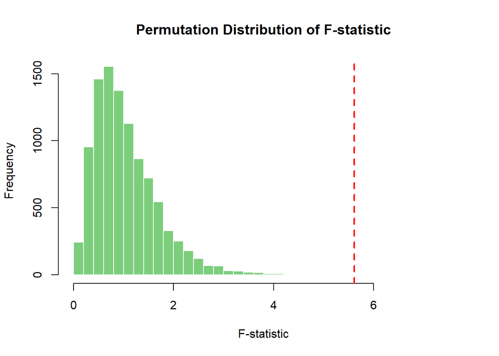

```r
# Plot the permutation F-statistics
hist(perm_F,
     breaks = 30,
     main = "Permutation Distribution of F-statistic",
     xlab = "F-statistic",
     col = "palegreen3",
     border = "white")

# F-statistic line
abline(v = observed_F,
       col = "red",
       lwd = 2,
       lty = 2)
```

A **permutation test** was performed on health outcomes by abortion policy to validate the findings from the Kruskal-Wallis test. The observed F-statistic was **5.608316**, and the permutation test yielded a **p-value of 0.0002**, which is statistically significant.

This result supports the conclusion that health outcomes vary significantly across abortion policy levels. The visualization of the permutation distribution shows that the observed F-statistic lies far to the right of the simulated null distribution, providing strong evidence that these differences are unlikely to have arisen by chance. **These findings underscore the measurable impact of abortion policy restrictiveness on broader health outcomes, indicating systemic disparities in public health quality across states.**

### OBGYN Ratios by Abortion Policy

```r
# Create the OBGYN ratio column
df <- df %>%
  mutate(obgyn_ratio = number_of_obstetricians_and_gynecologists_employed_2023 /
                       total_number_of_women_aged_15_44_2017)

# Summarize the ratio by abortion policy
ratio_summary <- df %>%
  group_by(abortion_policies) %>%
  summarise(mean_ratio = mean(obgyn_ratio, na.rm = TRUE),
            median_ratio = median(obgyn_ratio, na.rm = TRUE),
            sd_ratio = sd(obgyn_ratio, na.rm = TRUE))
# Print summary table
print(ratio_summary)
```

```
# A tibble: 7 × 4
  abortion_policies             mean_ratio median_ratio  sd_ratio
  <fct>                              <dbl>        <dbl>     <dbl>
1 most protective                 0.000367     0.000367 0.0000221
2 very protective                 0.000371     0.000385 0.000124
3 protective                      0.000405     0.000402 0.000198
4 some restrictions/protections   0.000418     0.000461 0.000167
5 restrictive                     0.000295     0.000238 0.000106
6 very restrictive                0.000318     0.000292 0.000105
7 most restrictive                0.000228     0.000179 0.000150
```

**Note:** It’s critical to consider the mismatch in timeframes for the data (OB-GYN numbers from 2023 and population data from 2017), which could introduce inaccuracies. This table serves as a starting point for understanding disparities in healthcare access by abortion policy and underscores the need for more recent and comprehensive data to draw robust conclusions.

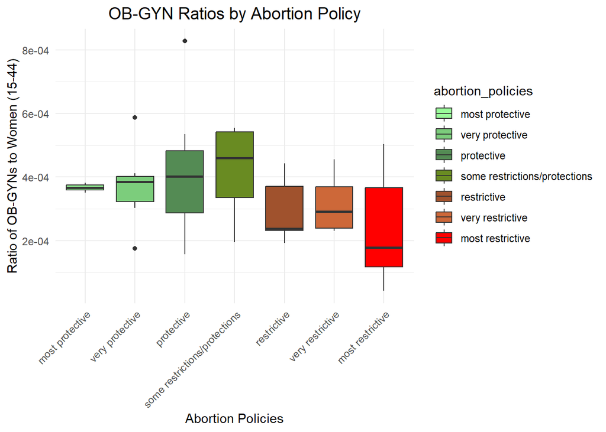

```r
ggplot(df, aes(x = abortion_policies, y = obgyn_ratio, fill = abortion_policies)) +
  geom_boxplot() +
  scale_fill_manual(values = c("palegreen", "palegreen3", "palegreen4",
                                "olivedrab4", "sienna", "sienna3", "red")) +
  labs(
    x = "Abortion Policies",
    y = "Ratio of OB-GYNs to Women (15-44)",
    title = "OB-GYN Ratios by Abortion Policy"
  ) +
  theme_minimal() +
  theme(
    axis.text.x = element_text(angle = 45, hjust = 1),
    plot.title = element_text(hjust = 0.5, size = 14)
  )
```

These findings suggest that states prioritizing access to abortion services may also allocate resources to ensure greater availability of OB-GYNs, enhancing access to comprehensive reproductive healthcare. On the other hand, states with restrictive abortion policies may not only limit reproductive healthcare access through policy but may also have fewer OB-GYNs available, compounding the barriers for women in accessing necessary medical care.

```r
set.seed(1234) # For reproducibility
N <- 10000 # Number of permutations
perm_F <- numeric(N)

for (i in 1:N) {
  permuted_data <- df
  permuted_data$obgyn_ratio <- sample(permuted_data$obgyn_ratio)

  perm_anova <- aov(obgyn_ratio ~ abortion_policies, data = permuted_data)
  perm_F[i] <- summary(perm_anova)[[1]][["F value"]][1]
}

# Step 3: Calculate the p-value
p_value <- mean(perm_F >= observed_F)

# Step 4: Print results
cat("Observed F-statistic:", observed_F, "\n")
```

```
Observed F-statistic: 5.608316
```

```r
cat("Permutation Test p-value:", p_value, "\n")
```

```
Permutation Test p-value: 3e-04
```

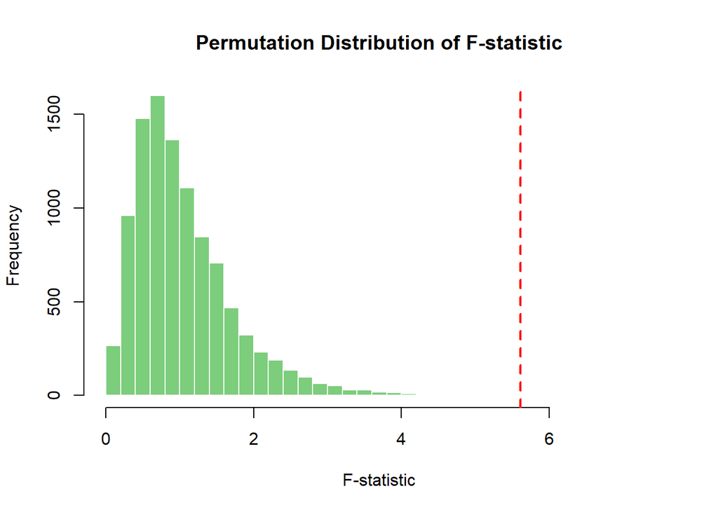

```r
hist(perm_F, breaks = 30,
     main = "Permutation Distribution of F-statistic",
     xlab = "F-statistic",
     col = "palegreen3",
     border = "white")
# Highlight the observed F-statistic
abline(v = observed_F, col = "red", lwd = 2, lty = 2)
```

# Conclusions

The findings across these analyses underscore the significant relationships between abortion policies and various dimensions of overall public health. States with more restrictive abortion policies tend to exhibit poorer rankings across critical health indicators, including overall health, healthcare quality and prevention, and health outcomes. This pattern is consistently supported by the results of Kruskal-Wallis tests, permutation tests, and visualization methods, suggesting systemic disparities in healthcare infrastructure and access.

The **overall health rankings** demonstrate a strong association with abortion policy restrictiveness, with protective policies aligning with better overall health rankings. This trend emphasizes the interconnectedness between reproductive rights and broader healthcare systems. Similarly, **healthcare quality and prevention rankings** highlight that states with restrictive abortion policies are not only less supportive of reproductive rights but also lag in preventative care and healthcare quality, key elements of robust public health systems.

The analysis of **coverage access and affordability** further reinforces this disparity. States with restrictive abortion policies exhibit poorer affordability and accessibility of healthcare services. This lack of investment in ensuring accessible care disproportionately impacts vulnerable populations, deepening systemic inequities. The trend is similarly evident in **Medicaid expansion status**, where states with restrictive abortion policies are less likely to have expanded Medicaid, limiting coverage for low-income individuals and exacerbating barriers to essential care.

The analysis of **state-mandated prescription contraceptive coverage** further reveals inconsistencies in the priorities of restrictive states. Despite framing their policies as “pro-life,” many fail to ensure access to affordable contraception, which is critical for preventing unintended pregnancies and managing health conditions like endometriosis or hormonal imbalances. This contradiction reflects a lack of investment in holistic healthcare strategies that would support individuals’ health and well-being.

Finally, the findings around **health outcomes rankings** reinforce these patterns. Restrictive abortion policies are linked to poorer health outcomes, suggesting that these states may deprioritize comprehensive health infrastructure, exacerbating disparities in access to essential services.

### Broader Implications:

These results collectively demonstrate that restrictive abortion policies are not isolated to reproductive rights but are indicative of broader systemic issues in public health. States with protective abortion policies tend to foster more equitable healthcare systems, ensuring access to both reproductive and general healthcare services. In contrast, restrictive states appear to perpetuate inequities, undermining both individual health and community well-being. These findings call for policymakers to consider the downstream effects of restrictive reproductive policies on broader healthcare access, outcomes, and equity.